# Review of decreasing cell adhesion protein during tumor progression

2019250160 biosystem leeyunji

#Proteogenomics of Non-smoking Lung Cancer in East Asia Delinates Molecular Signatures of Pathogenesis and Progression

## 1.Introduction

This study are collected cohort from in Taiwan, representing early stage, predominantly female, non-smoking lung adenocarcinoma and provided clinical feature for Taiwan cohort. Each gene had distinct regulation patterns during tumors progression. Especially, I focused on cell adhesion gene and DNA replication gene. In Figure 2I, we can see that cell adhesion protein is decreasing as the tumor stage increases(blue circle).

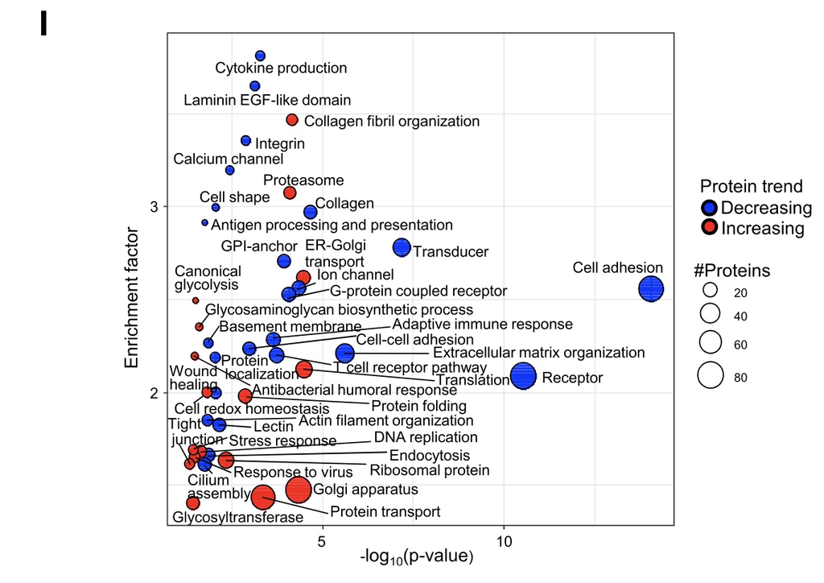

So I’ll process supplementary table to figure out gene related with cell adhesion pathway and plot adhesion protein level in LUAD compared with DNA replication protein level. As a result, I’ll check whether the actual TW cohort data shows down-regulation of adhesion pathway protein and consider the relationship between tumor and cell adhesion protein.

## 2. Data import

```r
library(readxl)
library(tidyverse)
```

I need information about clinical features of patients, pathway of gene, and mRNA,protein log2Tumor/NAT value.

```r
my_table1_S5 = read_excel('C:/Users/ddw20/Documents/bsms222_160_lee/TableS1.xlsx', sheet=5, na="NA")
my_table1_S6 = read_excel('C:/Users/ddw20/Documents/bsms222_160_lee/TableS1.xlsx', sheet=6, na="NA")
my_table3_S7 = read_excel('C:/Users/ddw20/Documents/bsms222_160_lee/TableS3.xlsx', sheet=7, na="NA")
my_table6_S2 = read_excel('C:/Users/ddw20/Documents/bsms222_160_lee/TableS6.xlsx', sheet=2, na="NA")
```

## 3. Data wrangling

Gene and related KEGG pathway is in `my_table3_S7(Table S3F)`. I want to know some genes involved in the adhesion pathway and also filter genes related to DNA replication pathway. so i used `filter` and `grepl`.

```r
adhesion<-my_table3_S7 %>% filter(grepl('adhesion', `C: KEGG pathway name`))%>%count(`T: Gene name`)%>% pull(`T: Gene name`)
replication<-my_table3_S7 %>% filter(grepl('replication', `C: KEGG pathway name`))%>%count(`T: Gene name`)%>% pull(`T: Gene name`)
```

`my_table6_S2(Table S6A)` has clinical features per patients. I converted row and column in my_table6_S2 to use `tidy data`.

```r
my_table6_S22<-as.data.frame(t(my_table6_S2))
colnames(my_table6_S22)<-my_table6_S22[1,]
my_table6_S22<-my_table6_S22[-c(1,2,3,4,5),]
my_table6_S22<-tibble::rownames_to_column(my_table6_S22, "ID")
```

In `my_table1_S6(Table S1E)`, there are so many genes and patients. I need expression level of only adhesion, replication gene.

```r
my_table1_S66<-my_table1_S6%>%filter(Gene %in% c(adhesion,replication))%>%select(Gene, my_table6_S22$ID)
my_table1_S66<-as.data.frame(t(my_table1_S66))
colnames(my_table1_S66)<-my_table1_S66[1,]
my_table1_S66<-tibble::rownames_to_column(my_table1_S66, "ID")
my_table1_S66<-my_table1_S66[-1,]
```

Using `pivot_longer`, i made tidy data and added new column ‘pathway’ that distinguish DNA replication and Adhesion.

```r
my_table1_S666<-my_table1_S66%>%pivot_longer(!ID,names_to="Gene",values_to="log2TN")%>%mutate(pathway=ifelse(Gene%in%c(repli),"DNAreplication","Adhesion"))
```

```r
my_table1_S55<-my_table1_S5%>%filter(gene %in% c(adhesion,replication))%>%select(gene, my_table6_S22$ID)
my_table1_S55<-as.data.frame(t(my_table1_S55))
colnames(my_table1_S55)<-my_table1_S55[1,]
my_table1_S55<-tibble::rownames_to_column(my_table1_S55, "ID")
my_table1_S55<-my_table1_S55[-1,]
my_table1_S555<-my_table1_S55%>%pivot_longer(!ID,names_to="Gene",values_to="Rlog2TN")%>%mutate(pathway=ifelse(Gene%in%c(replication),"DNAreplication","Adhesion"))
```

## 4.Visualizing

Since the log2 Tumor/NAT value for the JUN gene in some patients is NA, it is expressed in gray tiles.

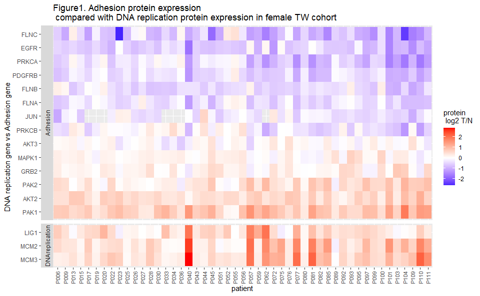

```r
merge(my_table1_S666,my_table6_S22,by='ID')%>%
  filter(!is.na(log2TN))%>%
  filter(Gender=="female")%>%
  select(ID,Gene,log2TN,pathway,AngiolymphaticInvasion)%>%
  mutate(log2TN=as.numeric(log2TN))%>%
  mutate(Gene=reorder(Gene, -log2TN)) %>%
  filter(!is.na(AngiolymphaticInvasion))%>%
  ggplot(aes(ID,Gene,fill=log2TN))+
  geom_tile()+
  scale_fill_gradient2(high ="red",mid="white",low="blue")+
  theme(axis.text.x = element_text(angle = 90,vjust = 0.5, hjust=1, size=8))+
  facet_grid(pathway~., switch="both", scales = "free_y", space = "free_y")+
  labs(x="patient",
       y="DNA replication gene vs Adhesion gene",
       title="Figure1. Adhesion protein expression \n compared with DNA replication protein expression in female TW cohort",
       fill="protein \n log2 T/N")
```

```r
NA
```

I associateed angiolymphatic invasion with cell adhesion. Instead of classifying into tumor stages, i used angiolymphatic invasion information to compare only the presence or absence of metastasis with adhesion. we can see that protein log2 T/N of down-regulated adhesion genes in fist plot is decreasing when angiolymphatic invasion is “yes”. median protein log2 T/N of boxplot is decreased. ( AKT, CRB2, PAK still remain an exception; they also participate in other pathways.) cells are connected to ECM and each other cell by cell-cell adhesion including adherens junctions and focal adhesions. AS adhesion genes are down-regulated, tumor cells invade and migrate into blood and lymph node.

**peer review pointed out that the boxplot of figure2 seems to be concentrated in the middle due to the presence of outliers and suggested to draw a larger, more dense plot by removing outliers. But it is not because of outliers that the box plot is concentrated in the middle. The log2 Tumor/NAT value ranges of up-regulation gene and down-regulation gene were initially different, so in order to compare the two plots together, the range of the y-axis was wide and the box was thus expressed as small. Also, if outlier data is really unnecessary, I think the number of outlier data should be very large. But the number of outliers is 0 to 5 for each gene. And looking at the plot, outliers do not seem to have much influence on the results I interpreted.

To make the box bigger,i tried to draw plots for down-regulation gene and up-regulation gene separately and then combine them using `plot_grid`. As a result, the y-axis values of each graph were further subdivided and the box was not concentrated only in the middle, but the y-axis ranges for up-regulation gene and down-regulation gene were different, so at a glance, it seemed as if the overall log2 T/N value of down-regulation was higher than that of up-regulation.

so instead of modifying the boxplot, a violin plot was added to indicate the overall distribution. I think the fact that the data were concentrated only in the middle has been resolved.**

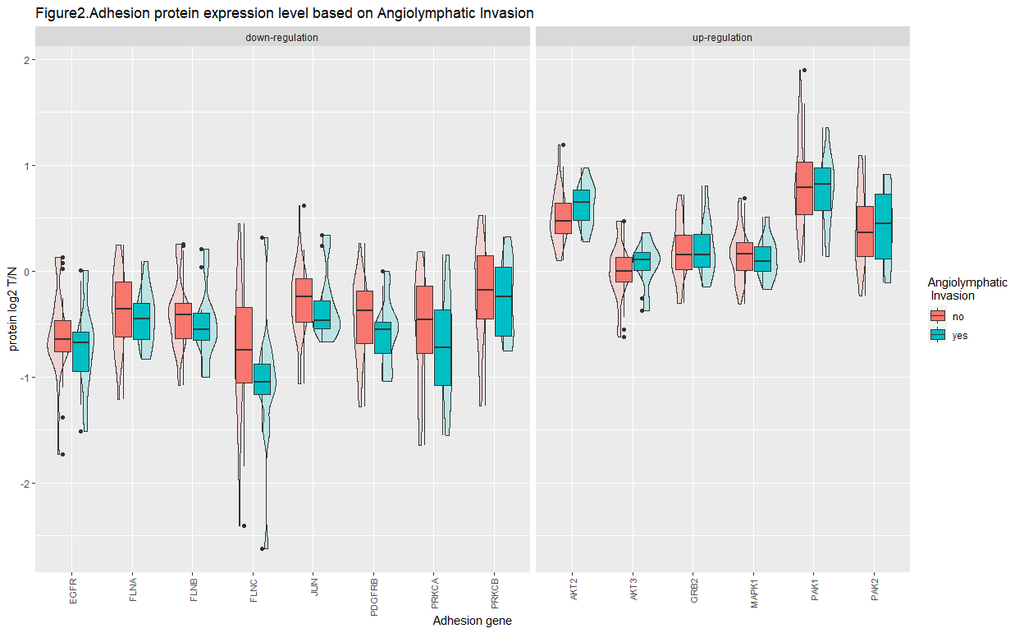

```r
merge(my_table1_S666,my_table6_S22,by='ID')%>%
  filter(!is.na(log2TN))%>%
  filter(Gender=="female")%>%
  select(ID,Gene,log2TN,pathway,AngiolymphaticInvasion)%>%
  mutate(log2TN=as.numeric(log2TN))%>%
  filter(!is.na(AngiolymphaticInvasion))%>%
  filter(pathway=="Adhesion") %>%
  mutate(regulation=ifelse(Gene%in% c("AKT2","AKT3","GRB2","MAPK1","PAK1","PAK2"),"up-regulation","down-regulation"))%>%
  ggplot(aes(Gene,log2TN))+
  geom_violin(aes(fill=AngiolymphaticInvasion), alpha=0.2,show.legend = FALSE)+
  geom_boxplot(width=0.6, aes(fill=AngiolymphaticInvasion))+
  theme(axis.text.x = element_text(angle = 90,vjust = 0.5, hjust=1, size=8))+
  facet_grid(~regulation, scales = "free_x", space = "free_x")+
  labs(x="Adhesion gene",
       y="protein log2 T/N",
       title="Figure2.Adhesion protein expression level based on Angiolymphatic Invasion ",
       fill="Angiolymphatic \n Invasion")
```

```r
NA
NA
```

## 5. Discussion

Patients with Angiolymphatic Invasion have down-regulation adhesion gene protein levels. Because cell migrations are depending on the cell adhesion properties. Dysregulation of adhesion gene is associated with many pathological states including Angiolymphatic Invasion, cancer metastasis. In addition to the genes shown in the Figure, there are many genes participating in cell to cell adhesion or communication. Also, the genes in the Figure are not only involved in the adhesion pathway. There are genes that is related with other pathway(eg.NSCLC pathway) as well as adhesion pathway, so some genes are upregulated despite of their adhesion pathway.In general, as the tumor stage increases, the adhesion protein log2Tumor/NAT decreases.

## 6. addition

First, peer review pointed out that the boxplot of figure2 seems to be concentrated in the middle due to the presence of outliers and suggested to draw a larger, more dense plot by removing outliers. But it is not because of outliers that the box plot is concentrated in the middle. The log2 Tumor/NAT value ranges of up-regulation gene and down-regulation gene were initially different, so in order to compare the two plots together, the range of the y-axis was wide and the box was thus expressed as small. Also, if outlier data is really unnecessary, I think the number of outlier data should be very large. But the number of outliers is 0 to 5 for each gene. And looking at the plot, outliers do not seem to have much influence on the results I interpreted.

To make the box bigger,i tried to draw plots for down-regulation gene and up-regulation gene separately and then combine them using `plot_grid`. As a result, the y-axis values of each graph were further subdivided and the box was not concentrated only in the middle, but the y-axis ranges for up-regulation gene and down-regulation gene were different, so at a glance, it seemed as if the overall log2 T/N value of down-regulation was higher than that of up-regulation.

so instead of modifying the boxplot, a violin plot was added to indicate the overall distribution. I think the fact that the data were concentrated only in the middle has been resolved.

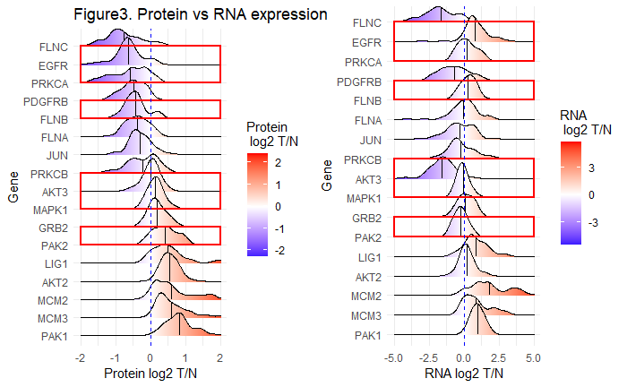

```r
d1<- merge(my_table1_S666,my_table6_S22,by='ID')%>%
  filter(!is.na(log2TN))%>%
  filter(Gender=="female")%>%
  select(ID,Gene,log2TN,pathway,AngiolymphaticInvasion)%>%
  mutate(log2TN=as.numeric(log2TN))%>%
  mutate(Gene=reorder(Gene, -log2TN)) %>%
  filter(!is.na(AngiolymphaticInvasion))%>%
  ggplot(aes(log2TN,Gene))+
  geom_density_ridges_gradient(aes(fill=stat(x)),quantile_lines = T, quantile_fun = mean)+
  scale_fill_gradient2(high = "red", mid = "white", low = "blue")+
  scale_x_continuous(limits=c(-2,2))+
  geom_rect(xmin=-2,xmax=2,ymin="PAK2",ymax="GRB2", color="red", lty=1, fill=NA, size=1)+
  geom_rect(xmin=-2,xmax=2,ymin="MAPK1",ymax="PRKCB", color="red", lty=1, fill=NA, size=1)+
  geom_rect(xmin=-2,xmax=2,ymin="FLNB",ymax="PDGFRB", color="red", lty=1, fill=NA, size=1)+
  geom_rect(xmin=-2,xmax=2,ymin="PRKCA",ymax="FLNC", color="red", lty=1, fill=NA, size=1)+
  theme_minimal()+
  geom_vline(xintercept=0, lty=2, color="blue")+
  labs(x="Protein log2 T/N",
       y="Gene",
       title="Figure3. Protein vs RNA expression ",
       fill="Protein \n log2 T/N")

d2<-merge(my_table1_S555,my_table6_S22,by='ID')%>%
  filter(!is.na(Rlog2TN))%>%
  filter(Gender=="female")%>%
  select(ID,Gene,Rlog2TN,pathway,AngiolymphaticInvasion)%>%
  mutate(Rlog2TN=as.numeric(Rlog2TN))%>%
  mutate(Gene=fct_relevel(Gene,levels = c("PAK1", "MCM3",   "MCM2",   "AKT2",   "LIG1",   "PAK2",   "GRB2",   "MAPK1",  "AKT3",   "PRKCB",  "JUN",    "FLNA",   "FLNB",   "PDGFRB", "PRKCA",  "EGFR",   "FLNC") )) %>%
  filter(!is.na(AngiolymphaticInvasion))%>%
  ggplot(aes(Rlog2TN,Gene))+
  geom_density_ridges_gradient(aes(fill=stat(x)),quantile_lines = T, quantile_fun = mean)+
  scale_fill_gradient2(high = "red", mid = "white", low = "blue")+
  scale_x_continuous(limits=c(-5,5))+
  geom_rect(xmin=-5.0,xmax=5.0,ymin="PAK2",ymax="GRB2", color="red", lty=1, fill=NA, size=1)+
  geom_rect(xmin=-5.0,xmax=5.0,ymin="MAPK1",ymax="PRKCB", color="red", lty=1, fill=NA, size=1)+
  geom_rect(xmin=-5.0,xmax=5.0,ymin="FLNB",ymax="PDGFRB", color="red", lty=1, fill=NA, size=1)+
  geom_rect(xmin=-5.0,xmax=5.0,ymin="PRKCA",ymax="FLNC", color="red", lty=1, fill=NA, size=1)+
  geom_vline(xintercept=0, lty=2, color="blue")+
  theme_minimal()+
  labs(x="RNA log2 T/N",
       y="Gene",
       fill="RNA \n log2 T/N")
plot_grid(d1,d2)
```

Since there was absence or presence of EGFR mutation in the provided data, i wondered if ther presence or absence of mutation affected the EGFR expression. therefore, a heatmap indicating the presence of EGFR mutation was created. and there was no significant difference between the person without the mutation and the person with it. it is regrettable that we have not clearly found what makes the difference in expression between RNA and protein in EGRR.

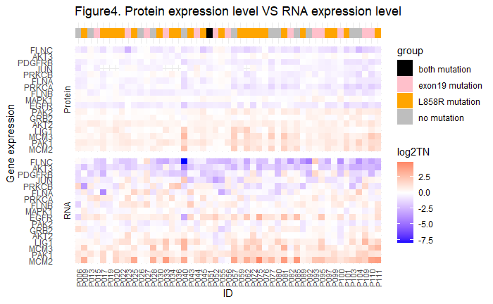

```r
my_table1_S5555<-my_table1_S555%>%
  mutate(state=ifelse(pathway%in% c("DNAreplication","Adhesion"),"RNA","na"))%>%mutate(log2TN=Rlog2TN)%>%select(ID,Gene,pathway,state,log2TN)
my_table1_S6666<-my_table1_S666%>%
  mutate(state=ifelse(pathway%in% c("DNAreplication","Adhesion"),"Protein","na"))

my_table2<-bind_rows(my_table1_S5555,my_table1_S6666)

my_table3<-merge(all,my_table6_S22, by='ID')%>%
  mutate(log2TN=as.numeric(log2TN))%>%
  filter(!is.na(log2TN))%>%
  filter(Gender=="female")%>%
  select(ID, Gene, log2TN,state, pathway,L858R,exon19del,AngiolymphaticInvasion)%>%
  mutate(group= case_when(L858R=="no"& exon19del=="no"~ "no mutation",
                          L858R=="yes"& exon19del=="no"~ "L858R mutation",
                          L858R=="no"& exon19del=="yes"~ "exon19 mutation",
                          TRUE~ "both mutation"))%>%
  mutate(log2TN=as.numeric(log2TN))%>%
  mutate(Gene=reorder(Gene, -log2TN)) %>%
  filter(!is.na(AngiolymphaticInvasion))

d3<-my_table3%>% ggplot(aes(ID,Gene,fill=log2TN))+
  geom_tile()+
  theme_minimal() +
  scale_fill_gradient2(high ="red",mid="white",low="blue")+
  theme(axis.text.x = element_text(angle = 90,vjust = 0.5, hjust=1, size=8))+
  facet_grid(state~., switch="both", scales = "free_y", space = "free_y")+
  geom_xsidetile(data=my_table3,aes(y =0, xfill = group)) +
   scale_xfill_manual(values=c("black","pink","orange","gray"))+
    ggside(collapse = "x")+
  labs(title="Figure4. Protein expression level VS RNA expression level ", y="Gene expression")
d3
```

```r
NA
```